# Terra Nova Electricity Usage

Kenneth Hubbard

2022-11-30

## Objectives

The purpose of this document is to investigate the electricity usage at Terra Nova. At the time of writing a smart meter has not been installed because of the age of the oil boiler. I fear that it will no longer work after the installation. I do have records of monthly usage and costs continuously from July 2016.

This will be an ongoing project with new objectives being identified as the current analysis continues. I know that the electricity usage has declined since the records began. The current objectives are as follows:

1. To determine the savings in kilo Watt hours (kWh) consumed over the last six years and to make a prediction of future demand;
2. To set targets for future savings;
3. To assess if changing supplier would result in future cost savings;
4. Attempt to determine what appliances use in the daily activities.

## Data storage

The electricity readings are added to an Calc spreadsheet where the charges are calculated. This spreadsheet is used to reconcile the bills that I receive from Ecotricity Ltd, my current supplier. The readings are taken first thing on the day following the last day of the month. A second reading is taken on the 7th day of each month and sent to my supplier for billing purposes.

The data is then added to a PostgreSQL database where the figures are directly downloaded for this analysis. A sample of the raw data is shown below:

```r
tail(df)
```

```
##    reading_date start_reading end_reading usage days daily_std_chg usage_chg
## 84   2022-08-31      61322.16    61456.20   134   24        0.3230    0.3609
## 85   2022-09-07      61456.20    61490.00    34    7        0.3230    0.3609
## 86   2022-09-30      61490.00    61636.00   146   23        0.3230    0.3609
## 87   2022-10-06      61636.00    61668.00    32    6        0.3708    0.3855
## 88   2022-10-31      61668.00    61811.26   143   25        0.3708    0.3855
## 89   2022-11-06      61811.26    61846.00    35    6        0.3708    0.3855
##    std_chg  used total  vat payable year month daily_usage
## 84    7.75 48.36 56.11 2.81   58.92 2022     8       5.583
## 85    2.26 12.27 14.53 0.73   15.26 2022     9       4.857
## 86    7.43 52.69 60.12 3.01   63.13 2022     9       6.348
## 87    2.22 12.34 14.56 0.73   15.29 2022    10       5.333
## 88    9.27 55.13 64.40 3.22   67.62 2022    10       5.720
## 89    2.22 13.49 15.72 0.79   16.50 2022    11       5.833
```

As can be seen from the sample of the last six records above in many cases there are two records for each month. These are aggregated into a new data frame containing one row for each month. The number of columns are also reduced to only those relevant to the analysis.

```r
tail(agg_elect)
```

```
##    year month usage days payable
## 71 2022     5   181   31   79.10
## 72 2022     6   168   30   73.84
## 73 2022     7   170   31   74.94
## 74 2022     8   170   31   74.94
## 75 2022     9   180   30   78.39
## 76 2022    10   175   31   82.91
```

### Annual totals

The full year totals are shown in the table below:

```r
annual
```

```
##   year usage days payable month fy_usage
## 1 2016  1838  184  306.83    68     3685
## 2 2017  3719  365  698.17    82     3719
## 3 2018  3562  365  731.37    82     3562
## 4 2019  3307  365  733.38    78     3307
## 5 2020  2712  366  658.21    78     2712
## 6 2021  2682  365  746.76    89     2682
## 7 2022  1887  310  798.05   119     2282
```

It should be noted that the year 2016 only contains six months data from July to December and 2022 only contains data up to October. I found an old reading for February 2016 of 40610 so only January’s data is missing for that year.

I ran some summary statistics to substitute the missing data detailed above. I have included the statistics below:

```r
usage_elect %>%
  group_by(month) %>%
  summarise(`Mean usage` = mean(usage),
            `Median usage` = median(usage),
            `Minimum` = min(usage),
            `Maximum` = max(usage),
            `Std dev` = sd(usage),
            'n' = n())
```

```
## # A tibble: 12 × 7
##    month `Mean usage` `Median usage` Minimum Maximum `Std dev`     n
##    <int>        <dbl>          <dbl>   <dbl>   <dbl>     <dbl> <int>
##  1     1         294.           314.     220     337      45.3     6
##  2     2         266.           288      195     305      48.2     6
##  3     3         271.           278.     201     320      49.3     6
##  4     4         252.           256.     192     302      48.2     6
##  5     5         245            242      181     298      48.6     6
##  6     6         232.           233      168     288      51.6     6
##  7     7         239.           243      170     300      55.0     7
##  8     8         246.           259      170     320      58.8     7
##  9     9         240.           250      166     306      55.1     7
## 10    10         253.           231      175     305      50.3     7
## 11    11         288.           285      235     348      48.4     6
## 12    12         291            298      232     341      39.1     6
```

The year 2016 usage was adjusted for February to December (43981 - 40610 kWh) + the median value for January (314 kWh) to give 3685 kWh. For this year November and December a forecast value of 201 kWh and 194 kWh were added to the current value to make 2282 kWh for the whole year.

## Initial analysis of savings

### Annual usage savings

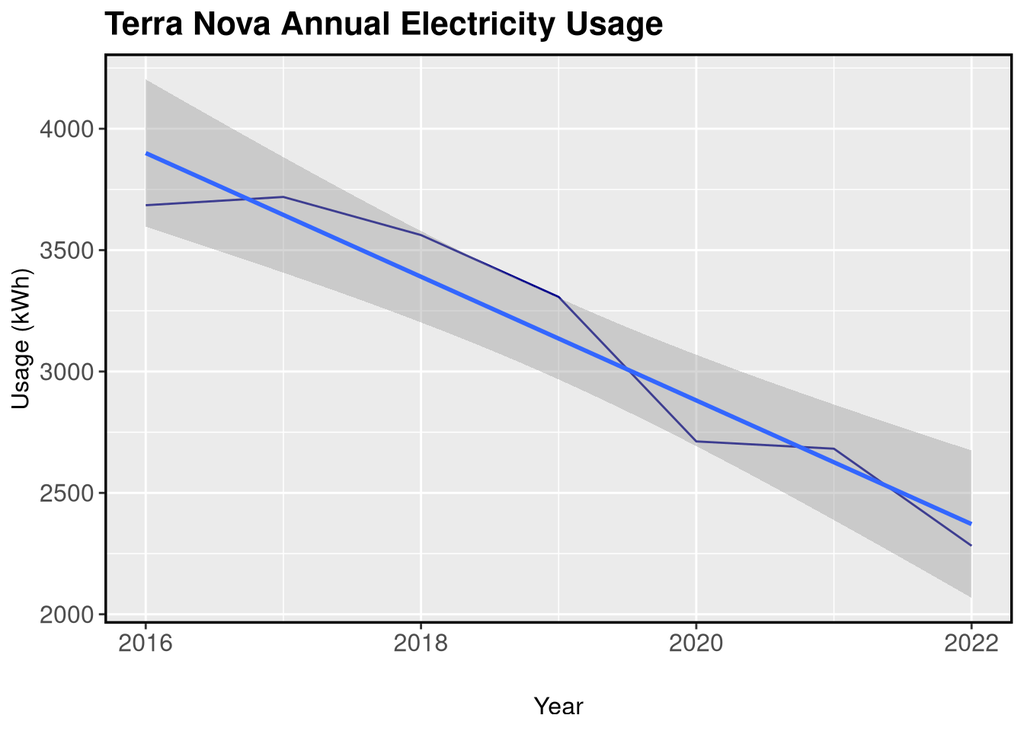

```r
annual %>%
  ggplot(aes(x=year, y=fy_usage)) +
  geom_line(color = 'dark blue') +
  ylab("Usage (kWh)") +
  xlab("Year") +
  ggtitle("Terra Nova Annual Electricity Usage") +
  theme(axis.text = element_text(size = 12),
        axis.title = element_text(size = 12),
        axis.title.x = element_text(margin = margin(t = 20, r = 0, b = 0, l = 0)),
        plot.title = element_text(size = 16, face = "bold"),
        panel.border = element_rect(color = "black", fill = NA, linewidth =  1.2),
        legend.position = "centre") +
  geom_smooth(method=lm) # add linear trend line
```

```
reduction = (usage 2022 - usage 2016) / usage 2016
          = (2282 - 3687) / 3687
          = -0.38 or -38%
```

The yearly totals are as follows:

```r
data.frame(year=annual[2:7,]$year, change=round((annual[2:7,]$fy_usage - annual[1:6,]$fy_usage) /
                annual[1:6,]$fy_usage,3))
```

```
##   year change
## 1 2017  0.009
## 2 2018 -0.042
## 3 2019 -0.072
## 4 2020 -0.180
## 5 2021 -0.011
## 6 2022 -0.149
```

```r
# calculate the variance for Jan-Oct for 2022 compared to same period in 2021
sum2022 <- sum(usage_elect$usage[usage_elect$year==2022 & usage_elect$month<11])
sum2021 <- sum(usage_elect$usage[usage_elect$year==2021 & usage_elect$month<11])
round((sum2022 - sum2021) / sum2021, 3)
```

```
## [1] -0.162
```

```r
# usage values for November and December 2021
usage_elect$usage[usage_elect$year == 2021 & usage_elect$month==11]
```

```
## [1] 240
```

```r
usage_elect$usage[usage_elect$year == 2021 & usage_elect$month==12]
```

```
## [1] 232
```

For 2022 compared for the same months January to October in 2021 the reduction in usage works out at -16.2%.

### Forecast for 2022 November and December

Based on a 16.2% reduction in electricity usage for the year up to October I have calculated the usage for November and December as follows:

- November = 240 x -16.2% = 201 kWh
- December = 232 x -16.2% = 194 kWh

### Costs

The amount charged by energy companies was usually in line with consumption until the end of 2021 when for some inexplicable reason costs went through the roof. This is especially perplexing as I have been with Ecotricity for over twenty years and all my electricity is derived from renewables. The unit cost of green energy has been going down for years so why unit costs are going up is an anomaly in a country with so called free market; a rigged market is a more appropriate description.

To illustrate the anomaly I have drawn the graphs of costs and usage one on top of the other.

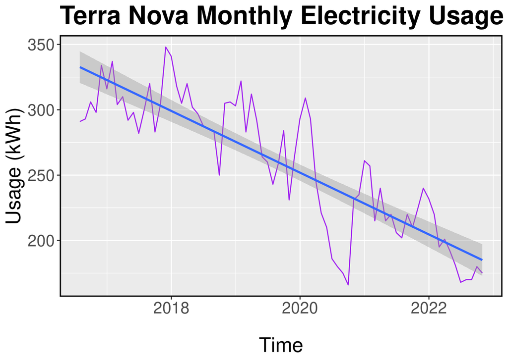

```r
print(fig3)
```

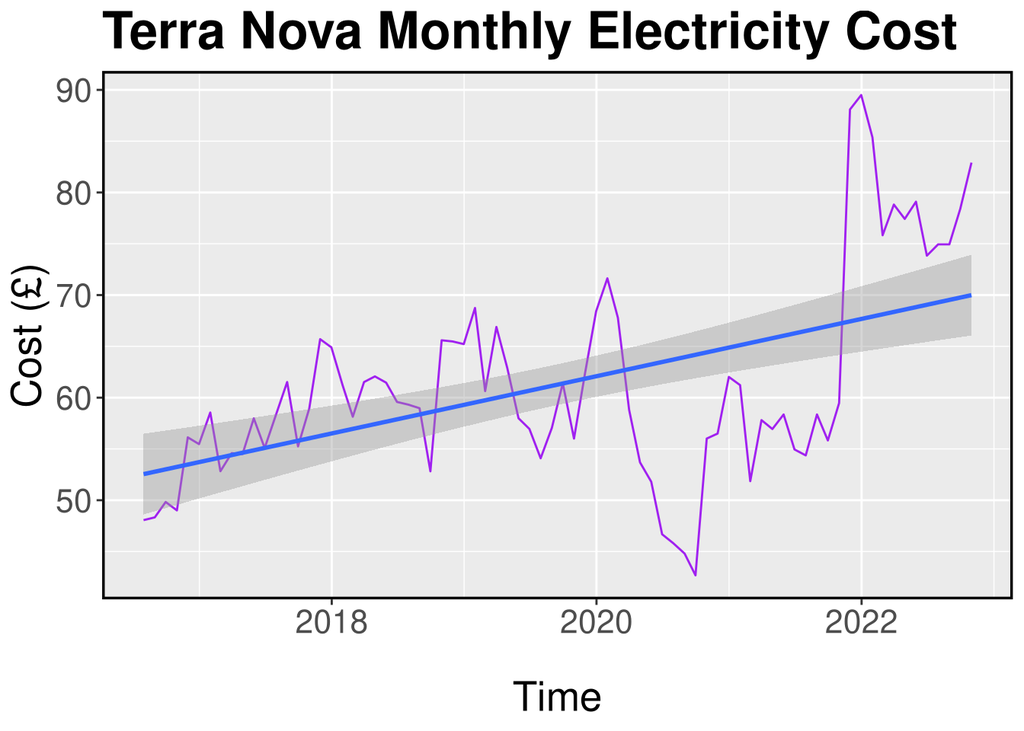

```r
print(fig6)
```